# Ethyl Carbamate Quantification in Table Wine

Layne Erickson

2026-10-13

# Step 1: Ensure instrument sensitivity

## Importing experimental data

```r
calibration <- read.csv("EC_calibration.csv")
```

## Initial plotting of our calibration curve

Evaluate how these calibration curves look visually first, always!

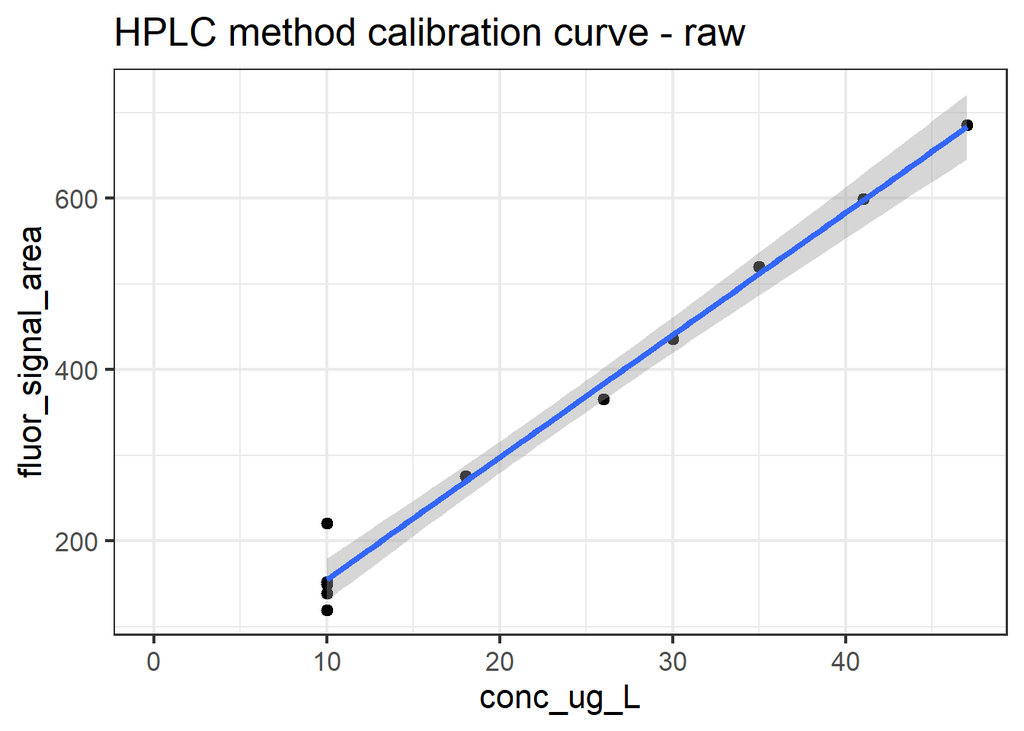

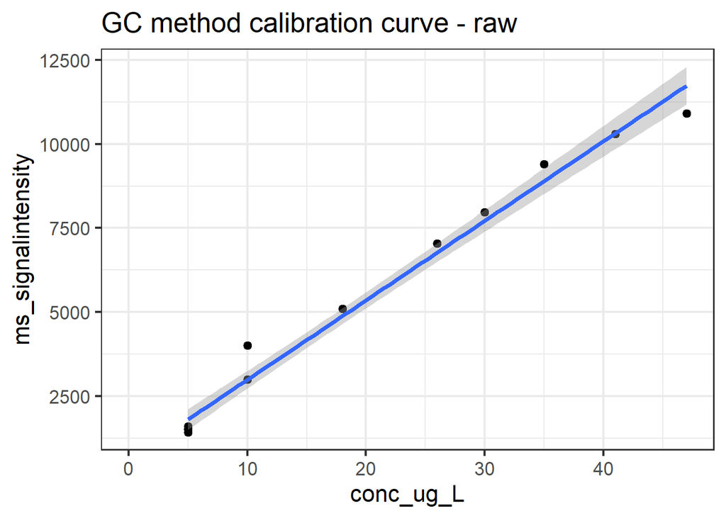

## Assessing model fit by plotting residuals

Evaluate how the model residuals confirm/deny what we observed visually

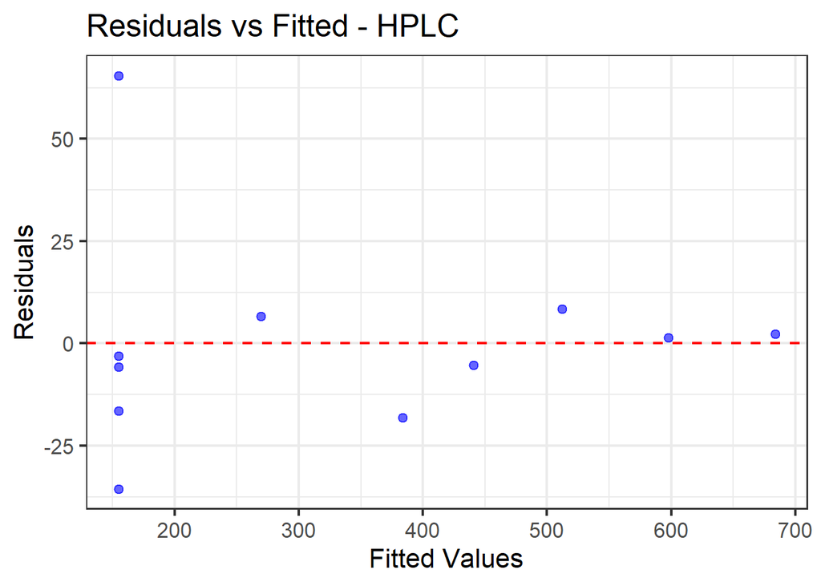

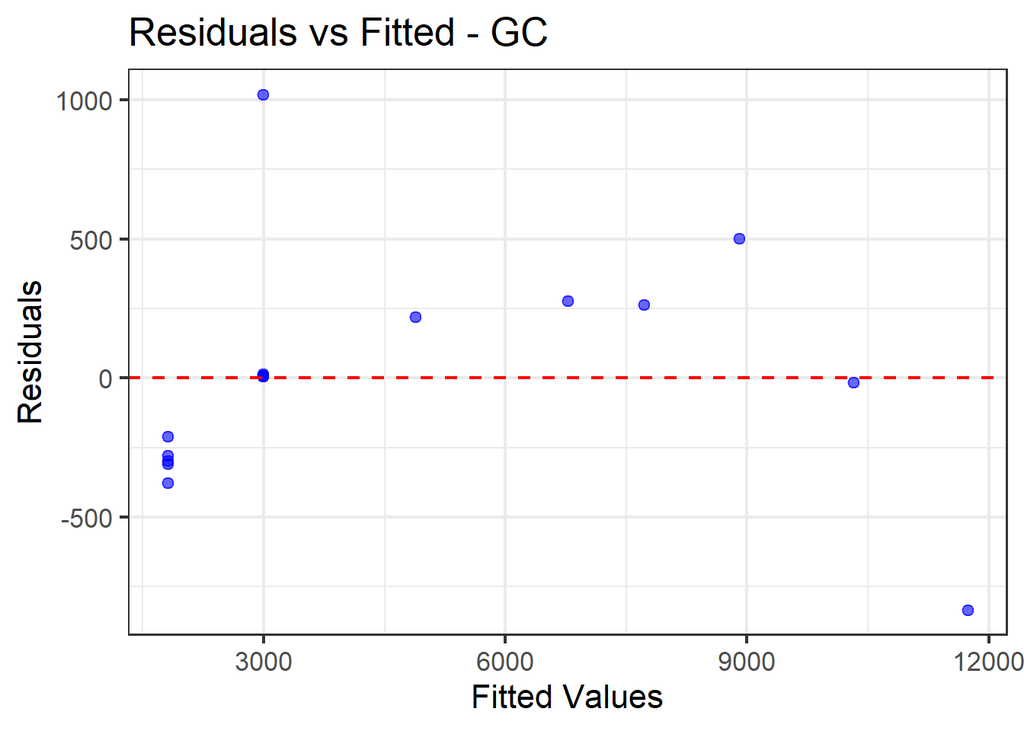

## Assessing model fit with model parameters

See slide 14 of lecture notes for interpretation of the model performance

```
##
## Call:
## lm(formula = fluor_signal_area ~ conc_ug_L, data = calibration)
##
## Residuals:
##     Min      1Q  Median      3Q     Max
## -35.545 -11.145  -3.045   4.458  65.455
##
## Coefficients:
##             Estimate Std. Error t value Pr(>|t|)
## (Intercept)  12.2208    15.6343   0.782    0.454
## conc_ug_L    14.2824     0.5981  23.878 1.89e-09 ***
## ---
## Signif. codes:  0 '***' 0.001 '**' 0.01 '*' 0.05 '.' 0.1 ' ' 1
##
## Residual standard error: 26.54 on 9 degrees of freedom
##   (8 observations deleted due to missingness)
## Multiple R-squared:  0.9845, Adjusted R-squared:  0.9827
## F-statistic: 570.1 on 1 and 9 DF,  p-value: 1.893e-09
```

```
##
## Call:
## lm(formula = ms_signalintensity ~ conc_ug_L, data = calibration)
##
## Residuals:
##     Min      1Q  Median      3Q     Max
## -832.84 -282.61    5.95  230.20 1019.45
##
## Coefficients:
##             Estimate Std. Error t value Pr(>|t|)
## (Intercept)  625.683    172.307   3.631  0.00272 **
## conc_ug_L    236.386      7.885  29.978 4.21e-14 ***
## ---
## Signif. codes:  0 '***' 0.001 '**' 0.01 '*' 0.05 '.' 0.1 ' ' 1
##
## Residual standard error: 433 on 14 degrees of freedom
##   (3 observations deleted due to missingness)
## Multiple R-squared:  0.9847, Adjusted R-squared:  0.9836
## F-statistic: 898.7 on 1 and 14 DF,  p-value: 4.214e-14
```

## Grubbs test

Can we remove any outliers in our calibration data?

```
## [1] "The calculated G value of 1.686 is higher than the critical value of 1.672, and thus the data point can be removed"
```

```
## [1] "The calculated G value of 1.789 is higher than the critical value of 1.672, and thus the data point can be removed"
```

```
##
## Call:
## lm(formula = fluor_signal_area ~ conc_ug_L, data = calibration)
##
## Residuals:
##     Min      1Q  Median      3Q     Max
## -22.167  -3.057  -1.223   8.867  15.956
##
## Coefficients:
##             Estimate Std. Error t value Pr(>|t|)
## (Intercept)  -6.1441     7.7971  -0.788    0.453
## conc_ug_L    14.7811     0.2863  51.621  2.2e-11 ***
## ---
## Signif. codes:  0 '***' 0.001 '**' 0.01 '*' 0.05 '.' 0.1 ' ' 1
##
## Residual standard error: 12.14 on 8 degrees of freedom
##   (9 observations deleted due to missingness)
## Multiple R-squared:  0.997,  Adjusted R-squared:  0.9966
## F-statistic:  2665 on 1 and 8 DF,  p-value: 2.197e-11
```

```
##
## Call:
## lm(formula = ms_signalintensity ~ conc_ug_L, data = calibration)
##
## Residuals:
##     Min      1Q  Median      3Q     Max
## -840.73 -187.63   92.59  194.28  523.73
##
## Coefficients:
##             Estimate Std. Error t value Pr(>|t|)
## (Intercept)  512.859    139.764   3.669  0.00283 **
## conc_ug_L    238.955      6.234  38.332 9.28e-15 ***
## ---
## Signif. codes:  0 '***' 0.001 '**' 0.01 '*' 0.05 '.' 0.1 ' ' 1
##
## Residual standard error: 339.4 on 13 degrees of freedom
##   (4 observations deleted due to missingness)
## Multiple R-squared:  0.9912, Adjusted R-squared:  0.9906
## F-statistic:  1469 on 1 and 13 DF,  p-value: 9.284e-15
```

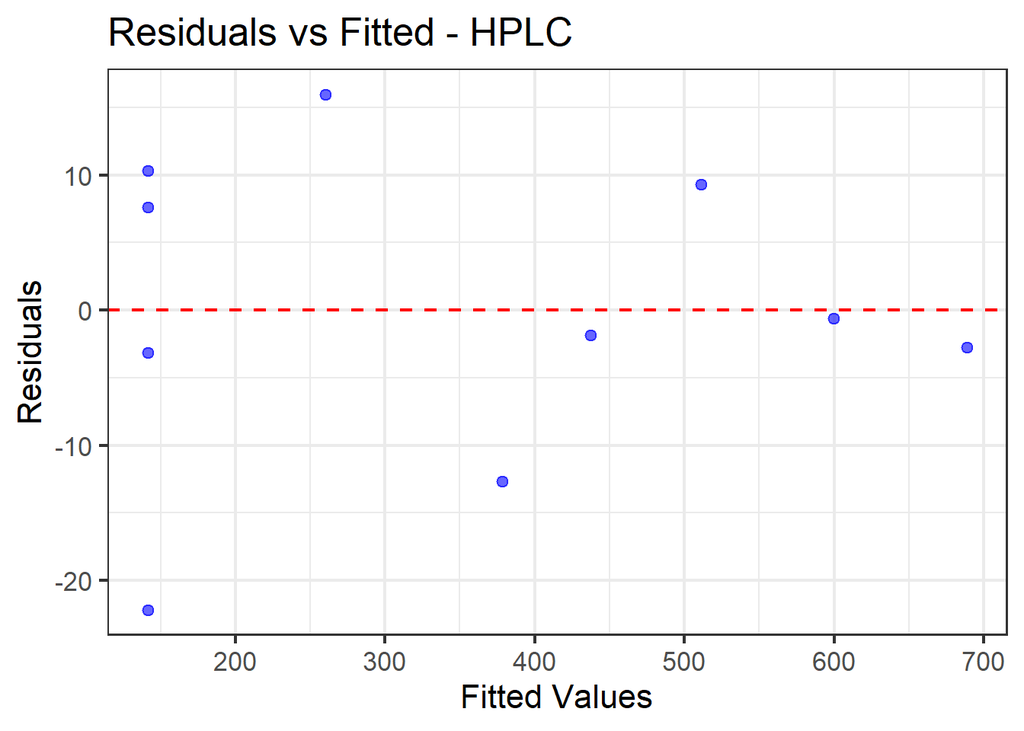

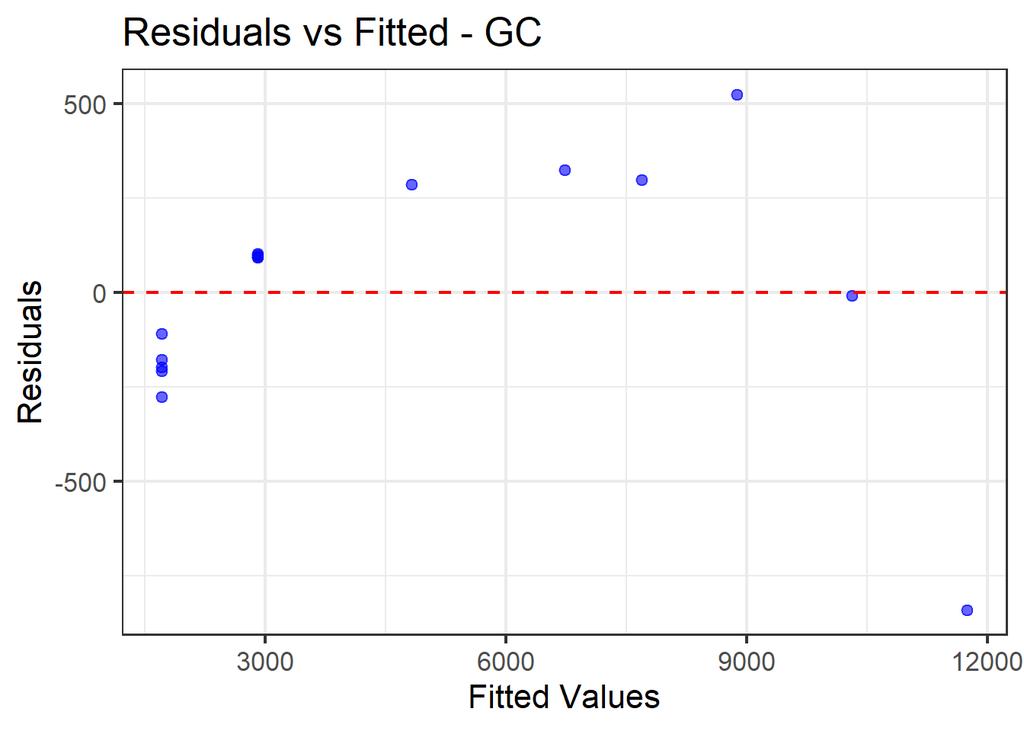

## Checking for linearity

One of our calibration curves does not look linear. How can we modify it to improve model performance?

```
##
## Call:
## lm(formula = ms_signalintensity ~ conc_ug_L, data = calibration %>%
##     filter(conc_ug_L < 40))
##
## Residuals:
##      Min       1Q   Median       3Q      Max
## -162.049  -82.049   -8.111  101.274  120.990
##
## Coefficients:
##             Estimate Std. Error t value Pr(>|t|)
## (Intercept)  289.372     48.057   6.021 8.66e-05 ***
## conc_ug_L    260.535      2.868  90.841  < 2e-16 ***
## ---
## Signif. codes:  0 '***' 0.001 '**' 0.01 '*' 0.05 '.' 0.1 ' ' 1
##
## Residual standard error: 104.2 on 11 degrees of freedom
##   (4 observations deleted due to missingness)
## Multiple R-squared:  0.9987, Adjusted R-squared:  0.9985
## F-statistic:  8252 on 1 and 11 DF,  p-value: < 2.2e-16
```

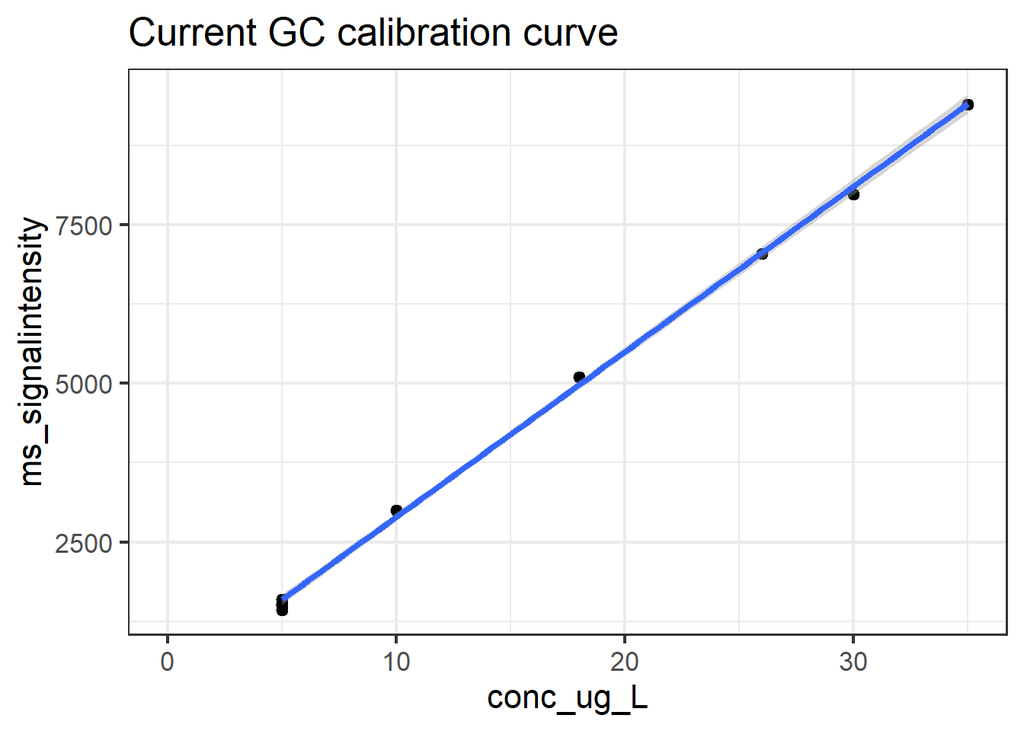

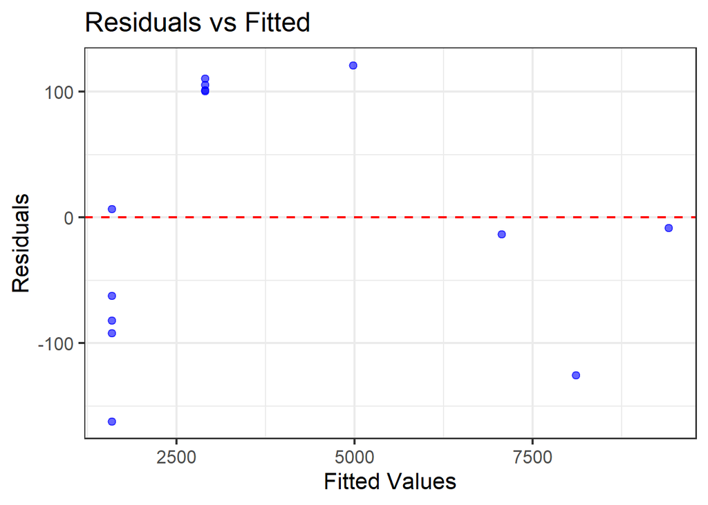

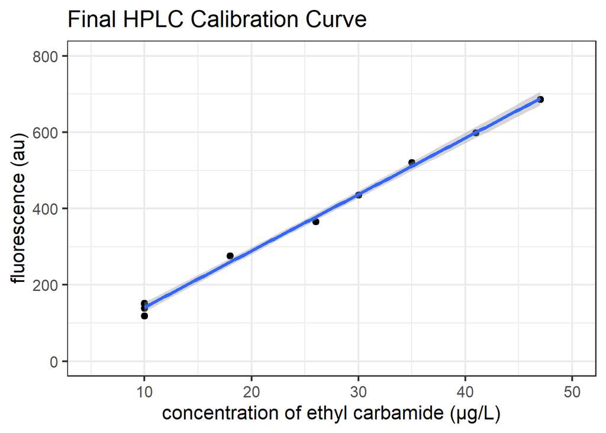

## Calculating LOD and LOQ

```
##
## Call:
## lm(formula = fluor_signal_area ~ conc_ug_L, data = calibration)
##
## Residuals:
##     Min      1Q  Median      3Q     Max
## -22.167  -3.057  -1.223   8.867  15.956
##
## Coefficients:
##             Estimate Std. Error t value Pr(>|t|)
## (Intercept)  -6.1441     7.7971  -0.788    0.453
## conc_ug_L    14.7811     0.2863  51.621  2.2e-11 ***
## ---
## Signif. codes:  0 '***' 0.001 '**' 0.01 '*' 0.05 '.' 0.1 ' ' 1
##
## Residual standard error: 12.14 on 8 degrees of freedom
##   (9 observations deleted due to missingness)
## Multiple R-squared:  0.997,  Adjusted R-squared:  0.9966
## F-statistic:  2665 on 1 and 8 DF,  p-value: 2.197e-11
```

```
##
## Call:
## lm(formula = ms_signalintensity ~ conc_ug_L, data = calibration %>%
##     filter(conc_ug_L < 40))
##
## Residuals:
##      Min       1Q   Median       3Q      Max
## -162.049  -82.049   -8.111  101.274  120.990
##
## Coefficients:
##             Estimate Std. Error t value Pr(>|t|)
## (Intercept)  289.372     48.057   6.021 8.66e-05 ***
## conc_ug_L    260.535      2.868  90.841  < 2e-16 ***
## ---
## Signif. codes:  0 '***' 0.001 '**' 0.01 '*' 0.05 '.' 0.1 ' ' 1
##
## Residual standard error: 104.2 on 11 degrees of freedom
##   (4 observations deleted due to missingness)
## Multiple R-squared:  0.9987, Adjusted R-squared:  0.9985
## F-statistic:  8252 on 1 and 11 DF,  p-value: < 2.2e-16
```

All calculated limits of detection

|  | HPLC (µg/L) | GC (µg/L) |
| --- | --- | --- |
| LOD (method 1) | 2.711 | 1.32 |
| LOD (method 2) | 3.294 | 0.769 |
| LOQ (method 1) | 8.214 | 4.001 |
| LOQ (method 2) | 9.98 | 2.331 |

# Step 2: Control experiments

## Standard Addition Experiments

We can use standard addition experiments to find systematic errors in our calibration curve. If you add 5 µL of a 1400 µg/mL solution to an initial volume of 1 mL of our wine sample four times, what is the initial concentration of ethyl carbamate?

```
##
## Call:
## lm(formula = y ~ x, data = SA)
##
## Residuals:
##      Min       1Q   Median       3Q      Max
## -21.0030 -10.7704  -0.6969  10.5482  22.4394
##
## Coefficients:
##             Estimate Std. Error t value Pr(>|t|)
## (Intercept) 188.4606     6.1142   30.82 1.53e-13 ***
## x             8.9151     0.3566   25.00 2.24e-12 ***
## ---
## Signif. codes:  0 '***' 0.001 '**' 0.01 '*' 0.05 '.' 0.1 ' ' 1
##
## Residual standard error: 13.67 on 13 degrees of freedom
##   (4 observations deleted due to missingness)
## Multiple R-squared:  0.9796, Adjusted R-squared:  0.9781
## F-statistic: 625.1 on 1 and 13 DF,  p-value: 2.236e-12
```

```
## [1] 27.10542
```

```
## [1] "The concentration determined by the standard addition is 21.14 µg/L which is similar to the concentration calculated with the calibration curve of 27.11 µg/L"
```

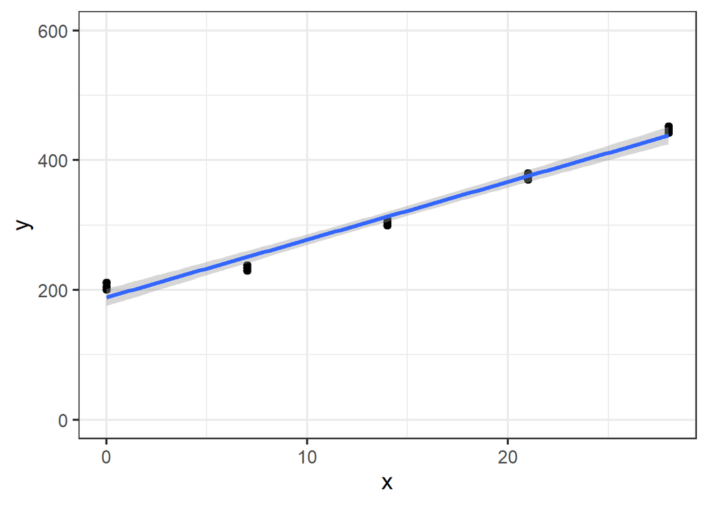

## Spike and recovery experiments

We want to make sure our sample preparation does not gain or lose ethyl carbamate. We add the equivalent of 90 µg/mL into our wine. What is our recovery %, based on the recovery data we collected?

```
## [1] "Our recovery is  100.32 %"
```

# Step 3: Identifying and reporting uncertainty

## HPLC method

### Unknown Concentrations

It’s finally time to ‘officially’ calculate the concentration of ethyl carbamate in two wine samples, WineA and WineB.

```
## [1] "The concentration of ethyl carbamide in wine A is  8.049  ug/L which corresponds to a concentration in the wine of 34.532  ug/L"
```

### Calculating the standard deviation of the measurement

```
## [1] "The ethyl carbamate concentration in our sample is  8  ±  0.5  µg/L from n =  5 , and a concentration in Wine A of 34.5  ±  2.3  µg/L from n =  5"
```

```
## [1] "The ethyl carbamate concentration in our sample is  6.6  ±  0.6  µg/L from n =  5 , and a concentration in Wine B of 28.2  ±  2.4  µg/L from n =  5"
```

### Calculating the 95% confidence interval

```
## [1] "The ethyl carbamate concentration in Wine A is 34.5 µg/L, 95% CI [27.1,42]"
```

## GC Method

Practice this on your own!

# Step 4: evaluating results

Do the measurements with the GC and the HPLC give us the same result? Are Wine A and Wine B the same?

## F-test:

This tells us if the standard deviations statistically different

### Comparing two methods

```
## [1] "The calculated F value of 0.94 is lower that the F table value of 6.39, so the standard deviations are not significantly different"
```

### Comparing two wines

```
## [1] "The calculated F value of 1.06 is lower that the F table value of 6.39, so the standard deviations are not significantly different"
```

## t-test:

This tells us if the means of the two categories are statistically different. We use different equations to calculate the t-value, depending on if the standard deviations are significantly different or not. Here, because they are not different, we can use the standard Student’s t-test equation.

### Comparing two methods

```
## [1] "The calculated t value of 7.56 is higher that the t-table value of 2.306, so the means are significantly different"
```

### Comparing two wines

```
## [1] "The calculated t value of 4.23 is higher that the t-table value of 2.306, so the means are significantly different"
```

## Built in R functions

Why isn’t there an easier way to do this? Without taking into account the uncertainty of our measurement, the data suggests we are less uncertain than we actually are!

[output not shown]

```
##
##  F test to compare two variances
##
## data:  calibration$unknownA_GC and calibration$unknownB_GC
## F = 2.626, num df = 4, denom df = 4, p-value = 0.3724
## alternative hypothesis: true ratio of variances is not equal to 1
## 95 percent confidence interval:
##   0.273412 25.221432
## sample estimates:
## ratio of variances
##           2.625993
```

```
##
##  Two Sample t-test
##
## data:  calibration$unknownA_GC and calibration$unknownB_GC
## t = 21.309, df = 8, p-value = 2.474e-08
## alternative hypothesis: true difference in means is not equal to 0
## 95 percent confidence interval:
##  45.23569 56.21460
## sample estimates:
## mean of x mean of y
##  1698.243  1647.518
```

# Summary of all the different data

All data summarized

| Value | HPLC | GC |
| --- | --- | --- |
| slope | 14.8 | 260.5 |
| s slope | 0.3 | 2.9 |
| intercept | -6.1 | 289.4 |
| s intercept | 7.8 | 48.1 |
| LOD (method 1) | 2.7 | 1.3 |
| LOQ (method 1) | 8.2 | 4 |
| LOD (method 2) | 3.3 | 0.8 |
| LOQ (method 2) | 10 | 2.3 |
| wine A (µg/L) | 34.5 | 23.2 |
| wine A uncertainty (µg/L) | 2.3 | 2.4 |
| wine A confidence interval (µg/L) | 7.4 | 7.7 |
| wine B (µg/L) | 28.2 | 22.4 |
| wine B uncertainty (µg/L) | 2.4 | 2.4 |
| wine B confidence interval (µg/L) | 7.7 | 7.7 |